# act 5: Paired-T Test vs Permutation Test

Dr. Islam

Feb 17, 2022

# Paired T-test

Given two populations whose measurements are paired is called a paired population. For example, let $\mu_1$ and $\mu_2$ be the means of two populations with (i) before and after measurements, (ii) measurements at two different time points, (iii) measurements of responses due to two different treatments, etc.

Note that the two sets of measurements are correlated.

We wish to test $H_0:\mu_d=0$ or $H_0:\mu_1-\mu_2=0$ against three possible alternatives:

$$H_1:\mu_1-\mu_2\gt 0$$

$$H_1:\mu_1-\mu_2\lt 0$$

$$H_1:\mu_1-\mu_2\ne 0$$
Given aforementioned facts, the test of $H_0:\mu_d=0$ or $H_0:\mu_1-\mu_2=0$ is called a paired T-test.

# Implementation of Paired T-test

In order to implement a paired T-test, we need a sample of $n$ paired measurements: $(x_1,y_1),(x_2,y_2 ),\cdots,(x_n,y_n )$.

Let $d_i=x_i-y_i; i=1,2,\cdots,n$, $\bar d=\bar x -\bar y$ and $s_d^2=\sum_{i=1}^n (d_i-\bar d)^2)/(n-1)$. Given these notations, the test of $H_0:\mu_d=0$ is performed by the test statistic
$$T=\frac{\bar x_d-\mu_d} {s_d/\sqrt n}\sim t_{n-1}$$
Under $H_0$, the statistic T follows a $t$-distribution with $df=n-1.$

Assumptions

It is to be noted that the paired $t$-test requires the following assumptions:

- the $n$ paired differences represent an SRS,
- either the population of paired differences is normal, or the sample size is large (i.e, $n\ge0$).
- the standard deviation of the population of paired differences is unknown.

$p-value$

The $p-value$ for a paired $t-test$ is defined as follows:

- $p-value=P(T>t)$ if $H_1:\mu_d\gt0$ (right-tailed test)
- $p-value=P(T<t)$ if $H_1:\mu_d\lt0$ (left-tailed test)
- $p-value=2\times P(T\gt |t|)$ if when $H_1:\mu_d\ne0$ (i.e., two-tailed test)

where the test statistic $T$ follows a t-distribution with $df=n-1$ and $t$ is the observed value of $T$.

Decision rule

- Reject $H_0:\mu_d=0$ at significance level $\alpha$ if $p-value\le\alpha$, otherwise fail to reject (i.e., accept) $H_0$.

# Permutation test

In the violation of the assumptions of the parametric t-test, a useful alternative is to employ simulation test. A permutation test is one of the most popular simulation test.

# Basic idea

- A permutation test builds a distribution by doing all possible permutations of observed sample values into two groups.
- When it is inconvenient to take all possible permutations, consider a reasonable number of permutations into two groups, without replacement.
- Usually, 1000-5000 simulations are considered adequate.

# Algorithm for a permutation test

The following algorithm can be adopted to employ a permutation test of $H_0:\mu_d=0$:

1. Compute the difference $d_i=x_i-y_i$ for all observed pairs $i=1,2,\cdots, n$ and compute the mean of $d_i$ for the observed data, say, $obs.diff=\bar x-\bar y$, given the observed data.
2. Recompute the difference $d_i=x_i-y_i$ and mean of $d_i$ after randomly switching the before and after scores for each individual. The most convenient way to do it is to multiple each difference score randomly by either +1 or -1, and then compute the mean.
3. Repeat step (ii) about 1000-5000 times, and denote the means by $perm.mean.diff$, say.
4. The p-value is then the proportion of means from steps (ii)-(iii) at least as extreme or more extreme than the mean obtained from step (i). Therefore, the left-, right- and two-tailed p.value is computed as follows:

$$pv.L=prop(perm.mean.diff\lt obs.diff)$$
$$pv.R=prop(perm.mean.diff\gt obs.diff)$$

$$pv.T=prop(abs(perm.mean.diff)\gt abs(obs.diff))$$

# Example of a Paired t-test

Given a paired, before-after data, we wish to perform a permutation test of $H_0:\mu=0$ where $\mu$ is the difference of mean in the paired population.

```r
library(tidyverse)
ba <-  read_csv("paired.csv")
```

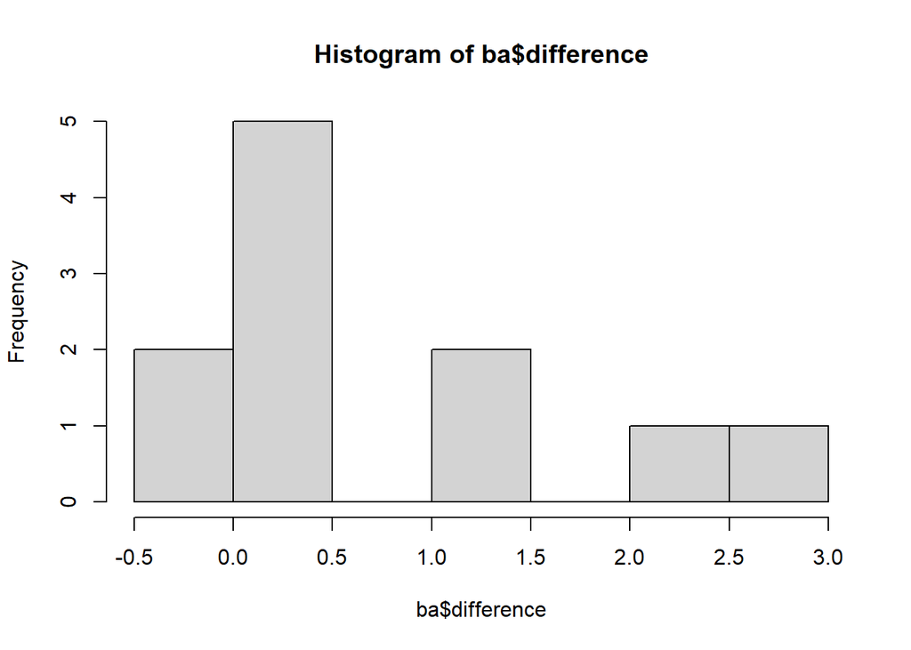

```r
ba$difference<-ba$before-ba$after
hist(ba$difference)
```

```r
shapiro.test(ba$difference)
```

```
    Shapiro-Wilk normality test

data:  ba$difference
W = 0.82621, p-value = 0.02081
```

```r
mdiff=mean(ba$difference)
mdiff
```

```
[1] 0.8
```

```r
# This is what we call observed mean difference

# Now, we would like to switch before after scores for each individuals by multiplying each difference score randomly by either +1 or -1, and then compute the mean of the difference.

# As an experiment or for a practice, let us do act of switching before-after score for each individuals and computing the mean of the difference:

mean1=mean(ba$difference * sample(c(-1,1), 11, replace = T))
mean1
```

```
[1] -0.7636364
```

```r
# another one, a second shuffle:

mean2=mean(ba$difference * sample(c(-1,1), 11, replace = T))
mean2
```

```
[1] 0.6363636
```

```r
# Now, do it 10,000 times:
diff.ba.means<-c()
for(i in 1:10000){
diff.ba.means[i] <- mean(ba$difference * sample(c(-1,1), 11, replace = T))
}

pvL=mean(diff.ba.means<mdiff)
pvR=mean(diff.ba.means>mdiff)
pvT=mean(abs(diff.ba.means)>abs(mdiff))

Lst=list("Left tailed p.value"=pvL, "Right tailed p.value"=pvR, "Two tailed p.value"=pvT)
Lst
```

```
$`Left tailed p.value`
[1] 0.996

$`Right tailed p.value`
[1] 0.0021

$`Two tailed p.value`
[1] 0.0045
```

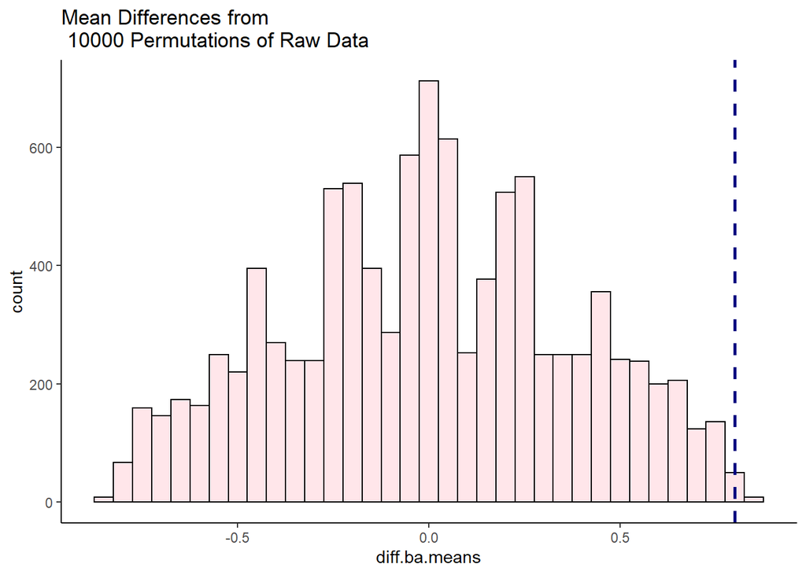

```r
# conclusion: This suggests that we have a highly significant p=0.002 difference between our ‘before’ and ‘after’ data within subjects.


# plot these results as a histogram:


df1 <- data.frame(diff.ba.means)
ggplot(df1, aes(x=diff.ba.means)) +
  geom_histogram(color="black", fill="pink", alpha=.4, binwidth = .05) +
  geom_vline(color="navy",lwd=1,lty=2,xintercept = mdiff) +
  theme_classic()+
  ggtitle("Mean Differences from \n 10000 Permutations of Raw Data")
```

```r
# do a paired t
t.test(ba$before, ba$after, paired = T, alt="l")
```

```
    Paired t-test

data:  ba$before and ba$after
t = 2.6667, df = 10, p-value = 0.9882
alternative hypothesis: true difference in means is less than 0
95 percent confidence interval:
     -Inf 1.343738
sample estimates:
mean of the differences
                    0.8
```

```r
t.test(ba$before, ba$after, paired = T, alt="l")[3]
```

```
$p.value
[1] 0.9881863
```

```r
t.test(ba$before, ba$after, paired = T, alt="g")[3]
```

```
$p.value
[1] 0.01181368
```

```r
t.test(ba$before, ba$after, paired = T, alt="t")[3]
```

```
$p.value
[1] 0.02362735
```